# The Grammar of Graphics: Designing and Transforming Data

author: Sandhya Kambhampati date: March 2019 font-family: ‘Helvetica’

# What is R?

“R is a language and environment for statistical computing and graphics”

> “The emphasis in *ggplot2* is reducing the amount of thinking time by making it easier to go from the plot in your brain to the plot on the page.”

> Wickham, 2012

# The philosophy of ggplot2

- A *ggplot2* graph is built up from a few basic elements:
- **Data**: the raw data you want to plot
- **Aesthetics**: including **Mapping** e.g., which variable is on the x-axis? the y-axis? Should the color/size/position of the plotted data that be mapped to some variable? (basically something you can see)
- **Geometries**: the geometric shapes that represent the data
- **Statistics**: statistical transformations that are used to summarize the data

Source: [Hopper (2014)] (http://tomhopper.me/2014/03/28/a-simple-introduction-to-the-graphing-philosophy-of-ggplot2/)

# Things to know

- Columns of data are mapped to aesthetics
- Legend maps the visual element and the data values
- Can’t create interactive graphics (see the ggvis package for this)

# Things to know

- Non-data related aspects controlled by theme
- background
- size of title
- font of the tick labels
- legend location

# Structure of the code

```r
ggplot(data = <data set>,
       aes(x = <x axis variable>,
           y = <y axis variable>,
           <other aesthetic mappings>),
       <other plot defaults>)
```

# How to install ggplot2

```r
#install the package
install.packages("ggplot2")

#load the package into your current project
library(ggplot2)
```

Make sure you have the most recent version of R to get the most recent version of *ggplot2*

# The Data: Road Casualties in Great Britain 1969–84

```r
data(Seatbelts)
s <- as.data.frame(Seatbelts)
```

# Add in the time series data

```r
ts <- data.frame(Year=floor(time(Seatbelts)),
Month=factor(cycle(Seatbelts),
labels=month.abb), Seatbelts)
```

# The Data: Road Casualties in Great Britain 1969–84

- **DriversKilled**: car drivers killed
- **drivers**: monthly totals of car drivers in Great Britain killed or seriously injured Jan 1969 to Dec 1984
- **front**: front-seat passengers killed or seriously injured
- **rear**: rear-seat passengers killed or seriously injured
- **kms**: distance driven
- **PetrolPrice**: price of petrol
- **VanKilled**: number of van (‘light goods vehicle’) drivers
- **law**: 0/1: was the law in effect that month?

Source: UK Driver Deaths via [R datasets](https://stat.ethz.ch/R-manual/R-devel/library/datasets/html/UKDriverDeaths.html)

# Look at your data

[output not shown]

# How to plot your data: quick plot

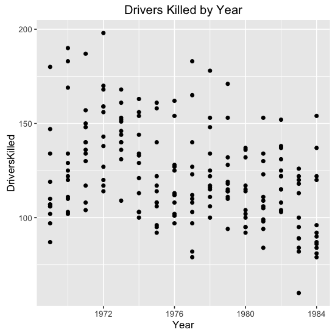

```r
qplot( data = ts,x= Year,y= DriversKilled, main= "Drivers Killed by Year")
```

# Basic Features of ggplot2

- Scatter Plot (geom_point)
- Bar Graph (geom_bar)
- Line Graph (geom_line)

# Scatter Plot

```r
ggplot(data = ts,
       aes(x = Year,
           y = DriversKilled)) +
  geom_point() +
  ggtitle("Drivers killed by Year")
```

# Scatter Plot

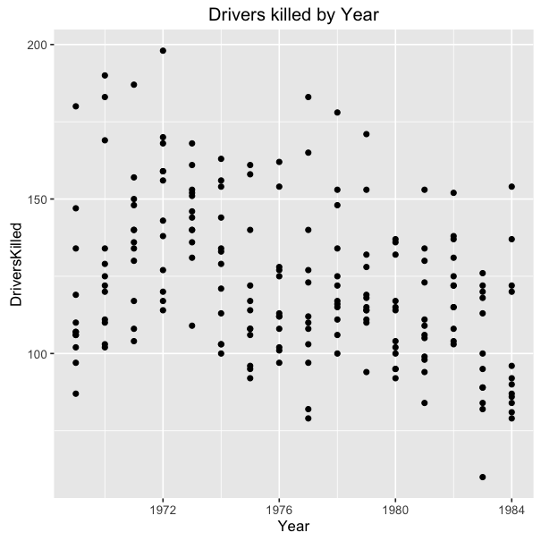

# Notice something?

```r
qplot( data = ts,
       x= Year,
       y= DriversKilled,
       main= "Drivers Killed by Year")
```

```r
ggplot(data = ts,
       aes(x = Year,
           y = DriversKilled)) +
  geom_point() +
  ggtitle("Drivers killed by Year")
```

# Bar Graph - simple

```r
ggplot(data = ts,
       aes(x = Year,
           y = VanKilled)) +
  geom_bar(stat = 'identity')
```

# Bar Graph - simple

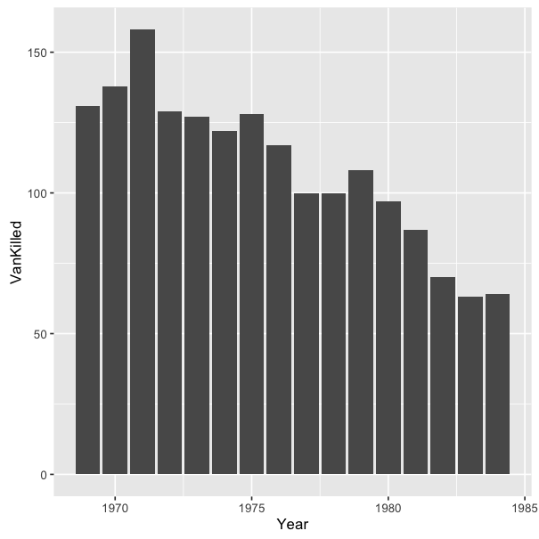

# Line Graph

```r
ggplot(data = ts,
       aes(x = Year,
           y = front)) +
  geom_point() +
  geom_line()
```

# Line Graph

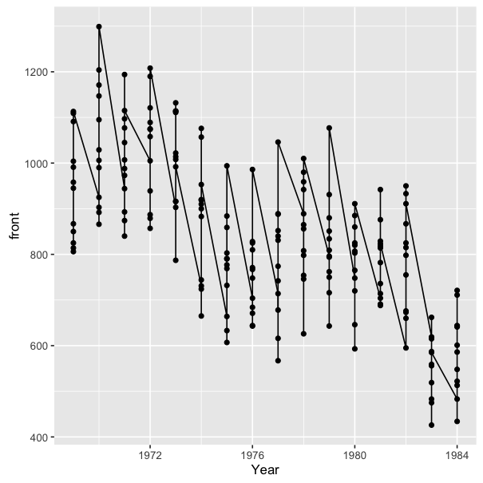

# Now, let’s make the charts a little more easy to read

# Scatter Plot - relabel y-axis

```r
ggplot(data = ts,
       aes(x = Year,
           y = DriversKilled)) +
  geom_point() +
  scale_y_continuous(limits = c(50,200))
```

# Scatter Plot - relabel y-axis

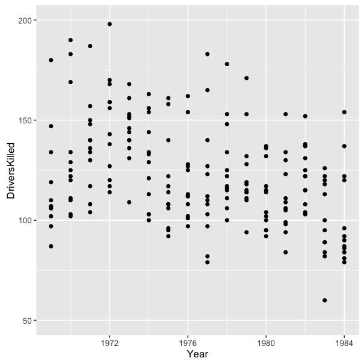

# Scatter Plot - color mapped to month

```r
ggplot(data = ts,
       aes(x = Year,
           y = DriversKilled,
           color = Month)) +
  geom_point()
```

# Scatter Plot - color mapped to month

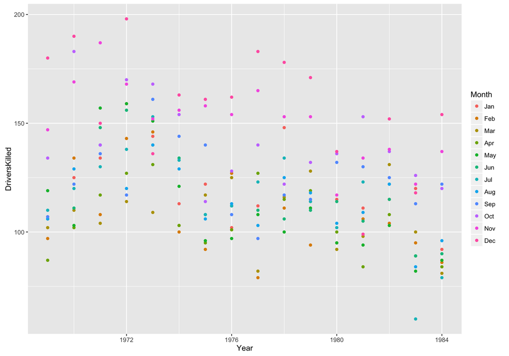

# Bar Graph - simple, transparent background

```r
ggplot(data = ts,
       aes(x = Year,
           y = VanKilled)) +
  geom_bar(stat = 'identity') +
  theme(panel.background = element_blank())
```

# Bar Graph - transparent background

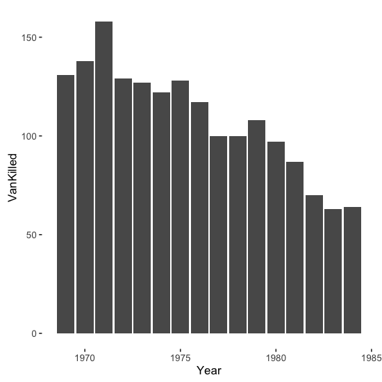

Source: [Hopper (2014)] (http://tomhopper.me/2014/03/28/a-simple-introduction-to-the-graphing-philosophy-of-ggplot2/)

# Advanced Features

- Text Labels
- Facetting
- Fitted Lines

# Text Labels

```r
ggplot(data = ts,
       aes(x = Month,
           y = DriversKilled)) +
        geom_text(aes(label = Year), size = 2)
```

# Text Labels

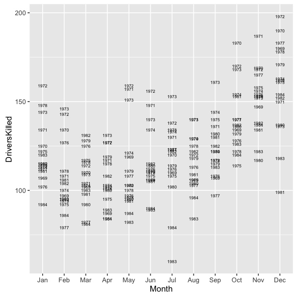

- Facetting allows you to split up your data by one or two variables
- *facet_grid()* places one or two variables in either vertical or horizontal directions
- *facet_wrap()* places facets next to each other, wrapping with a certain # of rows and/or columns

```
facet_grid(vertical ~ horizontal)

facet_wrap(~ variable, nrow = ___, ncol = ___)
```

# Advanced Line Graph

```r
ggplot(data = ts,
       aes(x = Year,
           y = DriversKilled)) +
  geom_line() +
  facet_wrap(~ Month)
```

# Advanced Line Graph

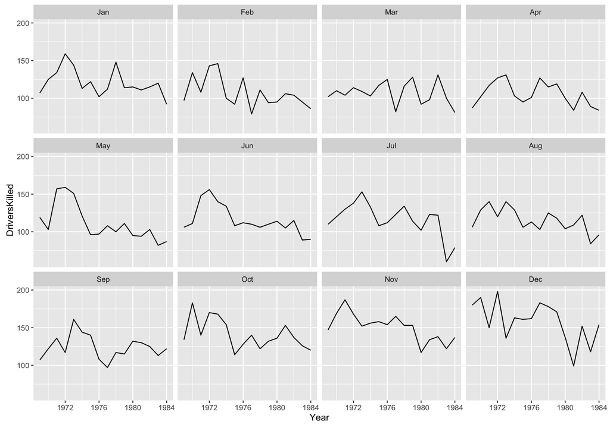

# Fitted Lines

- How do we draw a fitted line through these points?

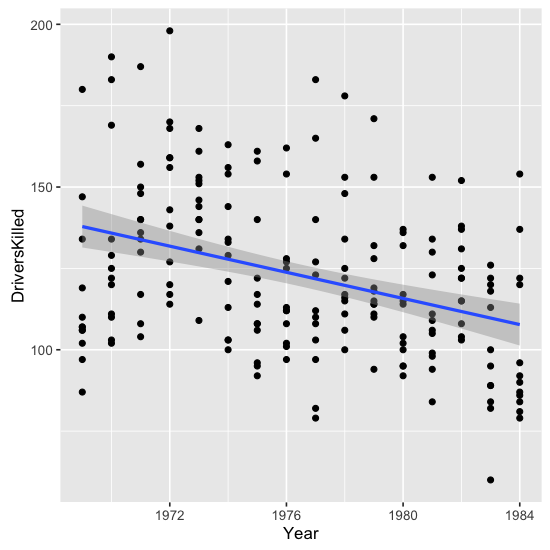

# Fitted Lines

```r
ggplot(data = ts,
       aes(x = Year,
           y = DriversKilled)) +
  geom_point() +
  stat_smooth(method = 'lm')
```

# Fitted Lines

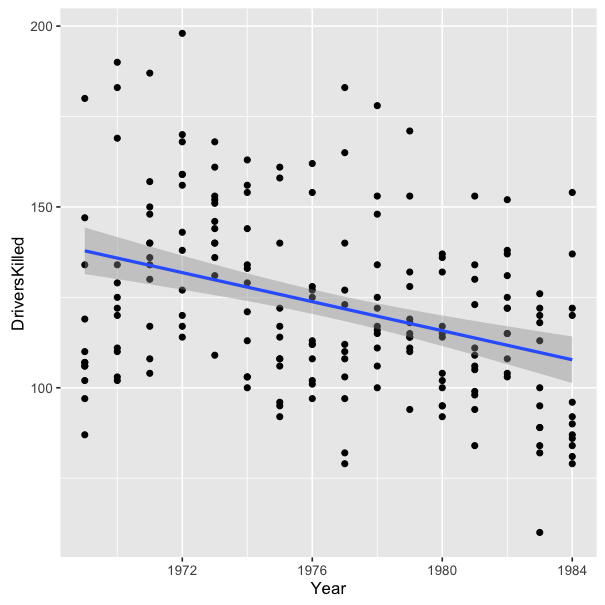

# Now, let’s combine those advanced features

```r
ggplot(data = ts,
       aes(x = Year,
           y = DriversKilled)) +
  geom_line() +
  facet_wrap(~ Month) +
  stat_smooth(method = 'lm')
```

# Advanced Line Graph

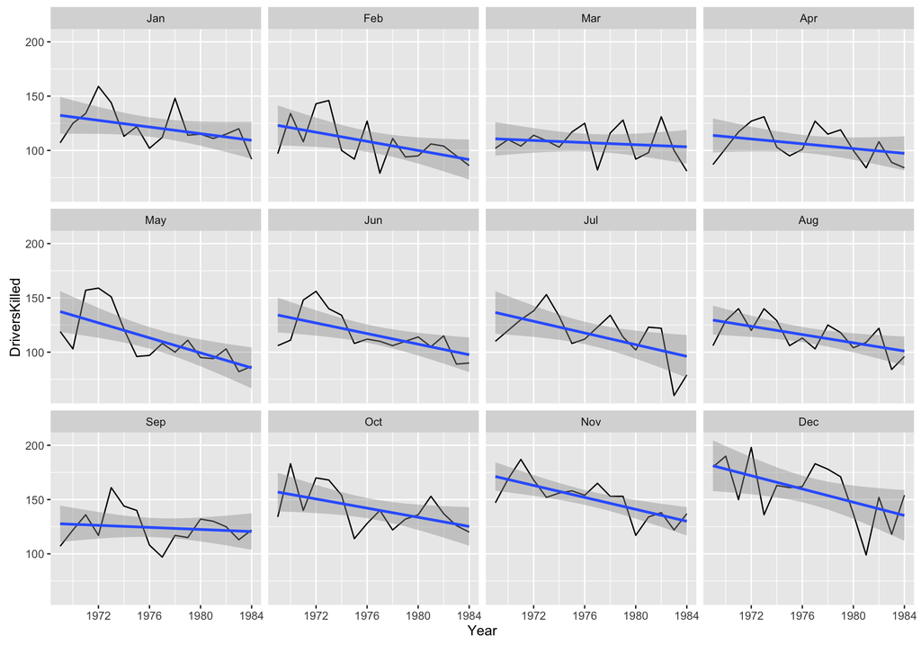

# Resources

- [“A Layered Grammar of Graphics”](http://vita.had.co.nz/papers/layered-grammar.html) by Hadley Wickham
- [“A Simple Introduction to the Graphing Philosophy of ggplot2”](http://tomhopper.me/2014/03/28/a-simple-introduction-to-the-graphing-philosophy-of-ggplot2/) by Tom Hopper
- [ggplot2 Cheat Sheet](https://www.rstudio.com/wp-content/uploads/2015/03/ggplot2-cheatsheet.pdf) by RStudio
- [ggplot2 Documentation](http://docs.ggplot2.org/current/) by Hadley Wickham & Winston Chang
- [Shapes and Line Types in R](http://www.cookbook-r.com/Graphs/Shapes_and_line_types/) by Winston Chang

# Thank You + Questions

Sandhya Kambhampati  
[@sandhya__k](https://twitter.com/sandhya__k)